# ESDA - Chronic diseases

Anaïs Ladoy

2023-04-04

**Import the datasets**

- `indiv`: Subset of Colaus participants eligible for this study (see selection procedure) within Lausanne.
- `laus$extent`: Boundary of the Lausanne area (polygon).
- `laus$sectors`: Statistical sectors of Lausanne (for mapping purpose only).
- `env`: Living environment (hectares) characteristics.

```r
indiv <- load_participants(con)
```

```
## Number of participants in Lausanne:  3216
## Pourcentage of the study dataset:  79.64
```

```r
laus <- load_boundaries(con)
env <- load_env()
```

*Specify covariates*

```r
cov.indiv <- c("age", "sex", "swiss", "cohabiting", "education", "difficulties", "smoking", "drinking", "inactivity")

cov.env <- c("PTOT", "ENV_INDEX", "NO2", "PM25", "NOISE", "GREEN_SP", "D_SPORT", "N_ACC_PED", "SOC_ECO_INDEX", "UNEMPLOYMENT", "LOW_EDUC", "HH_1PERS", "INCOME")
```

# Diabetes

Visualize diabetes events

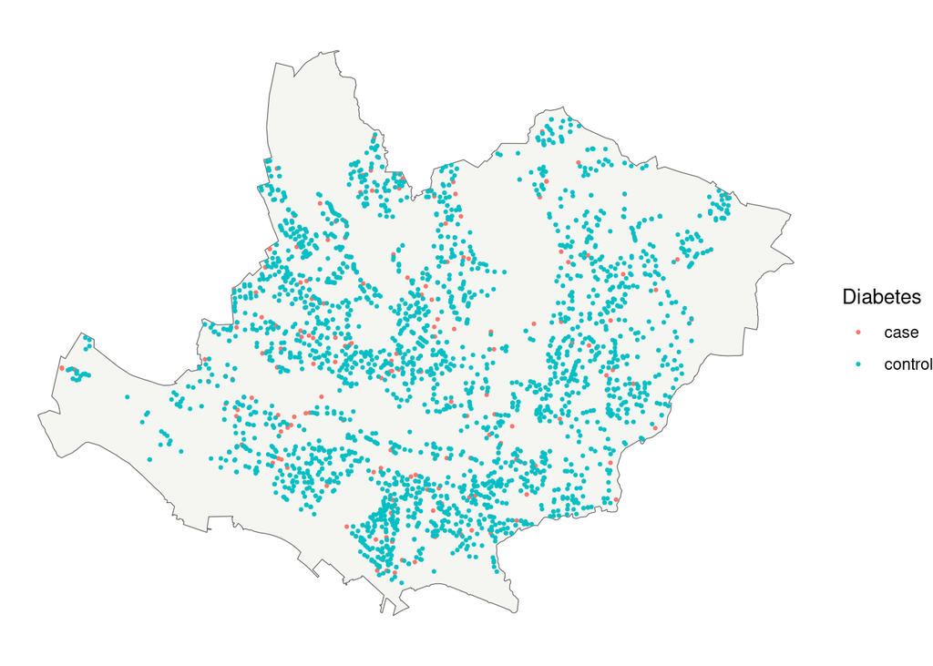

**Explore the spatial density of diabetes.**

```r
compare_spatial_dens(diab.cases, diab.controls)
```

```
## Scott's rule bandwidth for cases
##  sigma.x  sigma.y
## 446.9577 386.2069
## Scott's rule bandwidth for controls
##  sigma.x  sigma.y
## 316.4129 266.7408
```

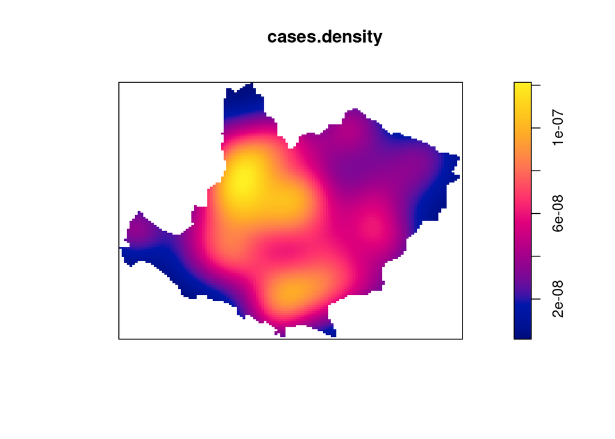

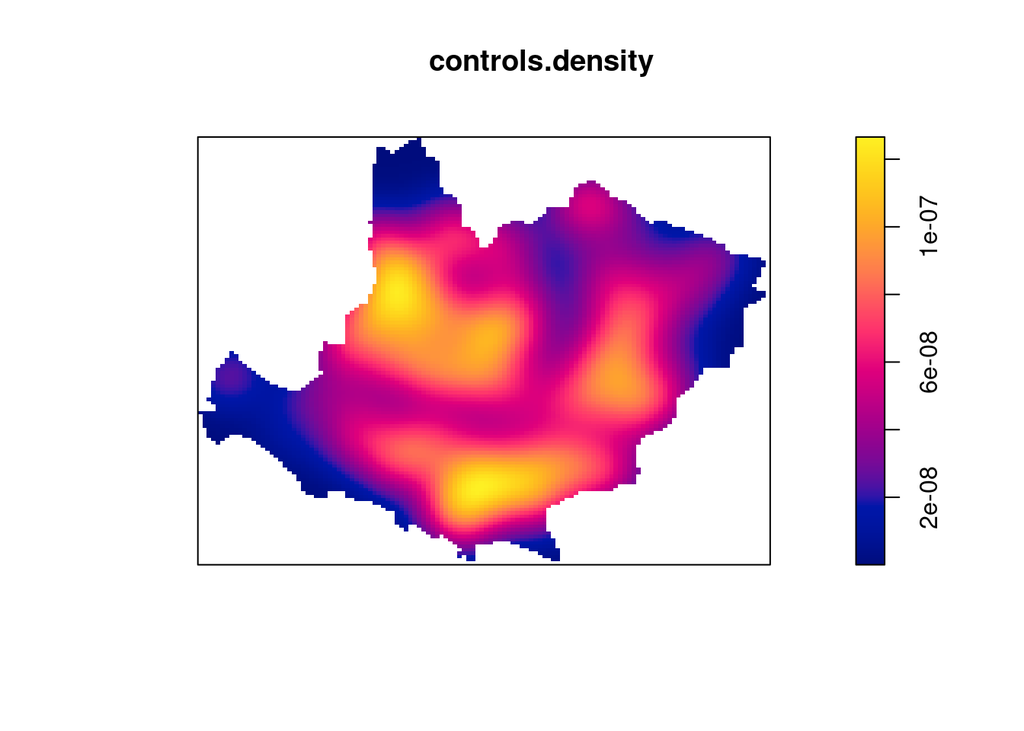

To construct the spatial density of diabetes, we used a two-dimensional product kernels using a Gaussian function and a bandwith defined by the Scott’s rule (*see p.133-136, Waller and Gotway (2004) for more details*). We applied an edge correction using the Jones-Diggle formula. The density function estimates suggest some local differences in the case and control patterns, especially near Montelly & Pontaise (high density of cases) and Chailly (high density of controls).

**Log ratio of spatial densities.**

Detect local clusters (*see p.164-171, Waller and Gotway (2004) for more details*). “Do cases and controls tend to occur in the same locations?” Assumption: bot case and control locations each represent a realization of a heterogeneous Poisson point process over the study area. We obtain a map indicating areas where events appear more or less likely to be cases than controls. Bandwith: We choosed a bandwith of 350m which is a compromise between the Scott’s rule estimated bandwith for cases and controls separatly.

```r
diab.lrr <- log_ratio_spatial_dens(diab.events, sigma=350)
```

```
## case has been selected as the case group
```

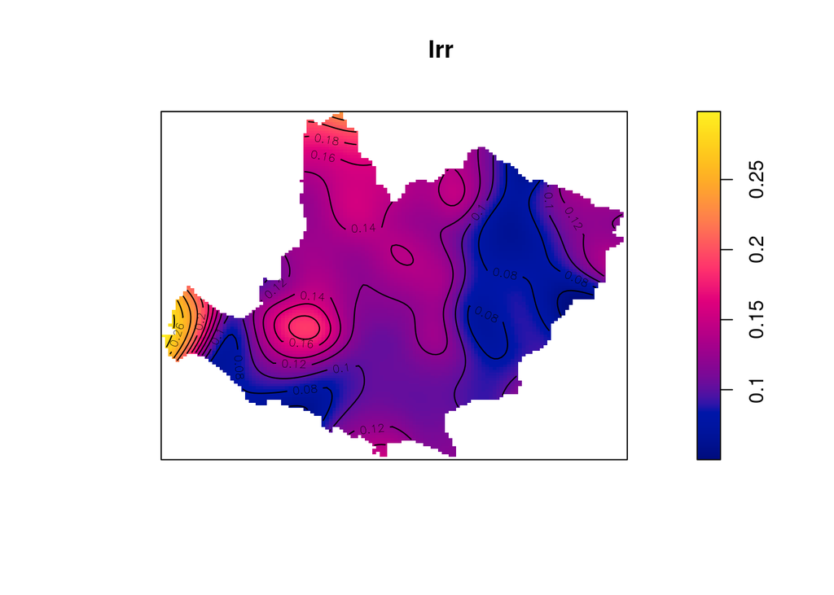

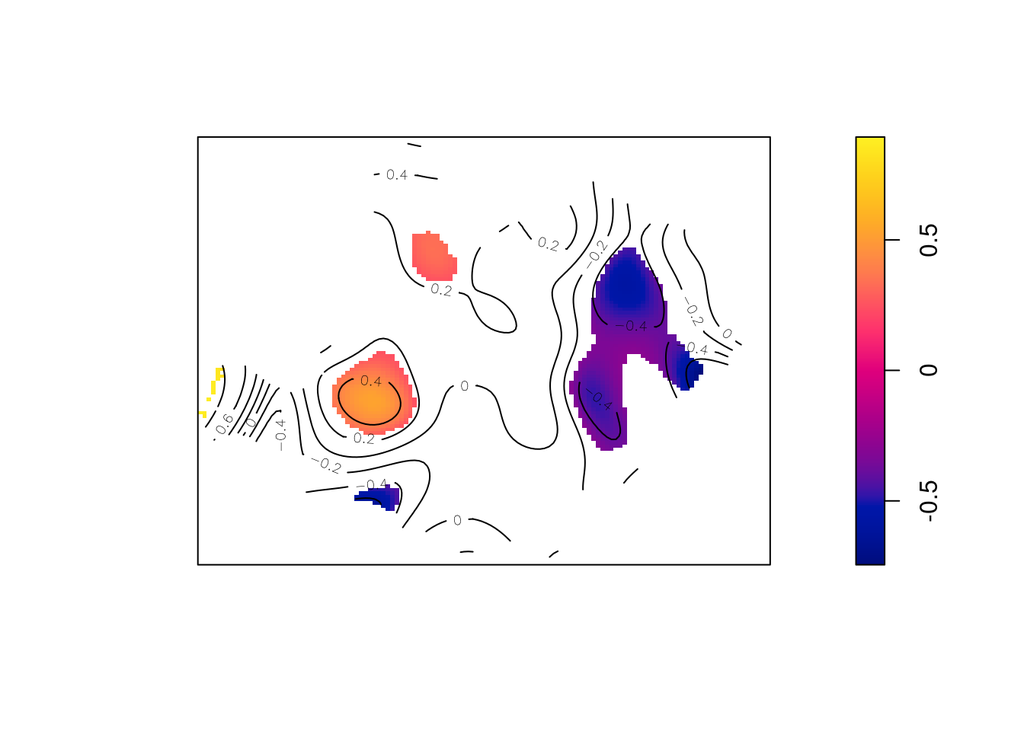

In the last map, orange areas represent parts of the study area where cases are clustered relative to controls beyond what is expected according to the random labeling hypothesis (tolerance=0.9, nsim=999). For the diabetes in Lausanne, we confirm our suggestions that there are clusters of cases near Montelly and Pontaise, and a deficit of cases near Chailly. However, there is no evidence of global clustering (p=0.425).

**Difference between K-functions of case and control processes.**

Using K-functions, we are interested of the distance to which any observed clustering tends to occur, averaged over the entire study area. “Do cases tend to occur near other cases in the same manner that controls tend to occur near other controls?”

```r
k_func_diff(diab.events)
```

```
## case has been selected as the case group
## case has been selected as the case group
```

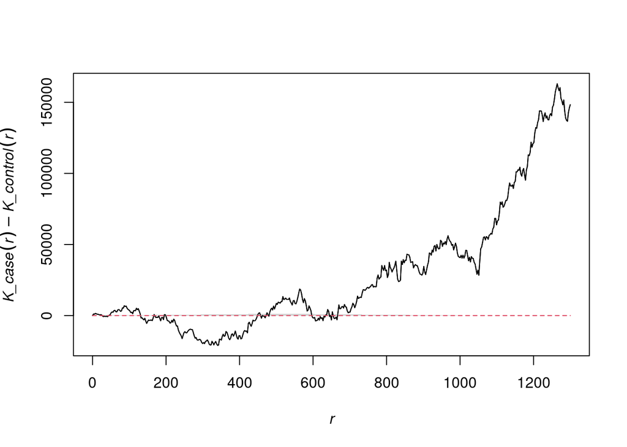

[output not shown]

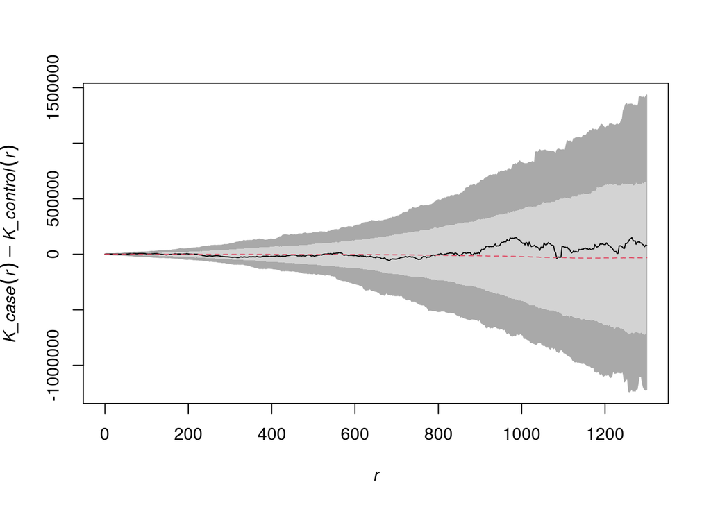

```
##
## Diggle and Chetwynd (1991) test for difference in K functions
##
## KD(r) = K_case(r) - K_control(r)
## case label:  case
## control label:  control
##
## null hypothesis: KD(r) = 0 for all r between 0 and 1299.884
## alternative hypothesis: KD(r) > 0 for at least one r between 0 and 1299.884
## test statistic: -7.826411
## p-value: 0.46
## nsim: 999
## simulation procedure: random labeling
```

### Extract areas of significant higher and lower risks of diabetes

Polygonize the image of the log relative risk surface.

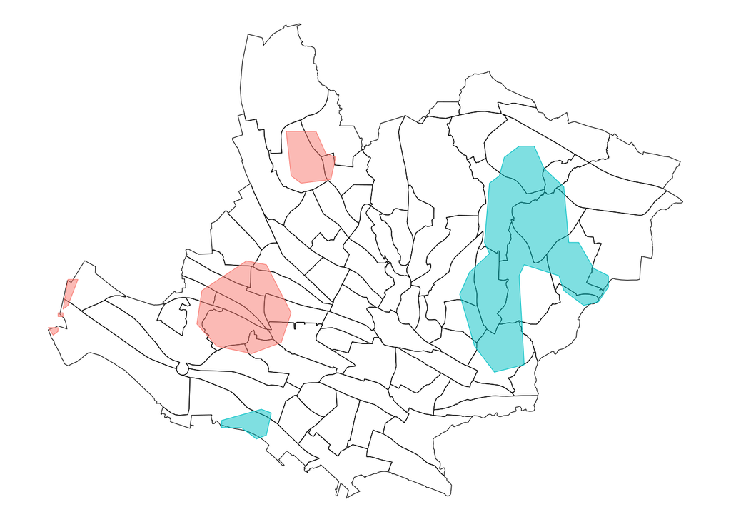

```r
map_significant_areas(diab.incid$lrr.poly, laus$sectors)
```

Compare neighborhood characteristics between areas of reduced and higher risk of diabetes.

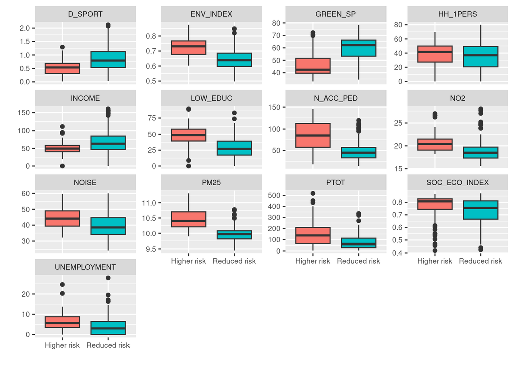

```r
compare_risk_areas(diab.incid$lrr.ha, cov.env)
```

```r
compare_risk_groups(diab.incid$lrr.ha, cov.env)
```

```
## PTOT
##
##  Wilcoxon rank sum test with continuity correction
##
## data:  PTOT by risk
## W = 13927, p-value = 3.043e-09
## alternative hypothesis: true location shift is not equal to 0
##
##
## ENV_INDEX
##
##  Wilcoxon rank sum test with continuity correction
##
## data:  ENV_INDEX by risk
## W = 15904, p-value < 2.2e-16
## alternative hypothesis: true location shift is not equal to 0
##
##
## NO2
##
##  Wilcoxon rank sum test with continuity correction
##
## data:  NO2 by risk
## W = 15070, p-value = 4.272e-14
## alternative hypothesis: true location shift is not equal to 0
##
##
## PM25
##
##  Wilcoxon rank sum test with continuity correction
##
## data:  PM25 by risk
## W = 17276, p-value < 2.2e-16
## alternative hypothesis: true location shift is not equal to 0
##
##
## NOISE
##
##  Wilcoxon rank sum test with continuity correction
##
```

[output cut: 60 more lines]

```
##
##  Wilcoxon rank sum test with continuity correction
##
## data:  HH_1PERS by risk
## W = 10465, p-value = 0.1667
## alternative hypothesis: true location shift is not equal to 0
##
##
## INCOME
##
##  Wilcoxon rank sum test with continuity correction
##
## data:  INCOME by risk
## W = 6275, p-value = 7.906e-07
## alternative hypothesis: true location shift is not equal to 0
```

**Summary**

While there is no evidence of global clustering of diabetes in Lausanne, we detected areas of significantly higher and lower risk.

*Areas of higher risk:*

- Montoie / Provence / Sébeillon
- Bossons / Bois-Mermet
- Bourdonnette

*Areas of lower risk:*

- Bellerive
- Victor-Ruffy / Sallaz / Devin / Craivavers / Av. Secrétan

*Areas of higher risk are characterized by:*

- higher population density (p<0.001)
- higher environmental exposures such as road noise and air pollution (p<0.001)
- lower greenspace (p<0.001)
- increased access to sport facility (p<0.001)
- lower neighborhood safety - higher pedestrian accidents (p<0.001)
- higher socio-economic vulnerability (p=0.001)
- higher unemployment rate (p<0.001)
- higher rate of low education (p<0.001)
- lower income (p<0.001)